# Delhi Air Pollution

Yashkumar Burnwal

2026-10-10

```r
# Load required libraries
library(tidyverse)
library(lubridate)
library(corrplot)
library(viridis)
library(scales)
library(gridExtra)
library(knitr)
library(kableExtra)
library(dplyr)
library(ggplot2)
library(reshape2)
```

# 1 Load and Inspect the Data

## 1.1 Read the Data

```r
# Read the CSV into a dataframe
pollution <- read.csv("Delhi_6Station_Hourly.csv", stringsAsFactors = FALSE)

# Basic dimensions
cat("Rows:", nrow(pollution), "| Columns:", ncol(pollution), "\n")
```

```
## Rows: 70227 | Columns: 21
```

```r
cat("Stations:", length(unique(pollution$loc)), "\n")
```

```
## Stations: 6
```

## 1.2 Data Structure

```r
str(pollution)
```

```
## 'data.frame':    70227 obs. of  21 variables:
##  $ loc    : chr  "AshokVihar" "AshokVihar" "AshokVihar" "AshokVihar" ...
##  $ PM2.5  : num  77 75 81 70 74 77 70 55 51 55 ...
##  $ year   : int  2018 2018 2018 2018 2018 2018 2018 2018 2018 2018 ...
##  $ month  : int  6 6 6 6 6 6 6 6 6 6 ...
##  $ day    : int  1 1 1 1 1 1 1 1 1 1 ...
##  $ hour   : int  0 1 2 3 4 5 6 7 8 9 ...
##  $ PM10   : num  274 237 219 217 226 208 274 276 228 208 ...
##  $ AT     : num  34.5 34 33.1 32.5 31.9 ...
##  $ BP     : num  975 976 991 998 998 ...
##  $ SR     : num  2 2 2 2 2.08 ...
##  $ RH     : num  62.2 62.3 65 66.9 69.8 ...
##  $ WS     : num  7.42 7.43 7.43 7.42 7.41 7.43 7.41 7.43 7.41 7.41 ...
##  $ WD     : num  129 129 129 129 129 129 129 129 129 129 ...
##  $ NO     : num  3.21 2.93 2.27 1.72 1.83 2.07 1.86 1.87 2.16 2.38 ...
##  $ NO2    : num  23.4 21.7 11.9 10.7 32.5 ...
##  $ SO2    : num  10.93 9.48 1.68 2.97 2.73 ...
##  $ Ozone  : num  98.1 97.8 46.3 35.9 26.6 ...
##  $ CO     : num  0.53 0.51 0.12 0.3 0.39 0.6 0.49 0.41 0.4 0.42 ...
##  $ Benzene: num  5.14 3.94 4.55 4.2 3.32 4.44 4.84 3.89 2.68 3.87 ...
##  $ NH3    : num  43 47.82 10.64 13.44 8.48 ...
##  $ NOx    : num  26.6 24.6 15.2 42.3 44.8 ...
```

## 1.3 Summary Statistics

```r
summary(pollution)
```

```
##      loc                PM2.5              year          month
##  Length:70227       Min.   :   0.03   Min.   :2018   Min.   : 1.000
##  Class :character   1st Qu.:  33.16   1st Qu.:2018   1st Qu.: 5.000
##  Mode  :character   Median :  58.00   Median :2019   Median : 7.000
##                     Mean   :  92.93   Mean   :2019   Mean   : 6.775
##                     3rd Qu.: 115.75   3rd Qu.:2019   3rd Qu.: 9.000
##                     Max.   :1000.00   Max.   :2019   Max.   :12.000
##       day             hour            PM10               AT
##  Min.   : 1.00   Min.   : 0.00   Min.   :   0.83   Min.   : 1.20
##  1st Qu.: 8.00   1st Qu.: 5.00   1st Qu.:  93.50   1st Qu.:20.95
##  Median :16.00   Median :11.00   Median : 168.50   Median :28.18
##  Mean   :15.71   Mean   :11.49   Mean   : 211.56   Mean   :26.67
##  3rd Qu.:23.00   3rd Qu.:17.00   3rd Qu.: 282.00   3rd Qu.:32.42
##  Max.   :31.00   Max.   :23.00   Max.   :1000.00   Max.   :48.20
##        BP               SR                 RH              WS
##  Min.   : 702.5   Min.   :   0.100   Min.   : 0.10   Min.   : 0.100
##  1st Qu.: 976.4   1st Qu.:   4.104   1st Qu.:44.83   1st Qu.: 0.550
##  Median : 982.5   Median :  23.480   Median :66.70   Median : 0.930
##  Mean   : 982.6   Mean   : 132.199   Mean   :64.17   Mean   : 1.372
##  3rd Qu.: 990.1   3rd Qu.: 202.990   3rd Qu.:85.30   3rd Qu.: 1.420
##  Max.   :1094.2   Max.   :1000.380   Max.   :99.80   Max.   :47.470
##        WD               NO              NO2              SO2
##  Min.   :  0.07   Min.   :  0.10   Min.   :  0.10   Min.   :  0.10
##  1st Qu.:103.65   1st Qu.:  2.32   1st Qu.: 19.85   1st Qu.:  8.82
##  Median :170.97   Median :  6.03   Median : 32.75   Median : 12.55
##  Mean   :175.88   Mean   : 32.60   Mean   : 41.81   Mean   : 14.96
##  3rd Qu.:251.07   3rd Qu.: 24.65   3rd Qu.: 55.03   3rd Qu.: 18.70
##  Max.   :357.35   Max.   :499.80   Max.   :323.60   Max.   :190.38
##      Ozone              CO            Benzene            NH3
##  Min.   :  0.10   Min.   : 0.000   Min.   : 0.000   Min.   :  0.10
##  1st Qu.:  5.62   1st Qu.: 0.700   1st Qu.: 1.100   1st Qu.: 22.65
##  Median : 17.88   Median : 1.000   Median : 2.480   Median : 29.88
##  Mean   : 36.70   Mean   : 1.383   Mean   : 4.069   Mean   : 32.96
##  3rd Qu.: 54.25   3rd Qu.: 1.530   3rd Qu.: 4.950   3rd Qu.: 40.58
##  Max.   :199.90   Max.   :10.000   Max.   :83.500   Max.   :172.80
##       NOx
##  Min.   :  0.10
##  1st Qu.: 14.27
##  Median : 24.80
##  Mean   : 49.45
##  3rd Qu.: 51.57
##  Max.   :500.00
```

## 1.4 First Few Rows

```r
head(pollution) %>%
  kable(caption = "First 6 rows of the dataset") %>%
  kable_styling(bootstrap_options = c("striped", "hover", "condensed"),
                full_width = FALSE, font_size = 12)
```

First 6 rows of the dataset

| loc | PM2.5 | year | month | day | hour | PM10 | AT | BP | SR | RH | WS | WD | NO | NO2 | SO2 | Ozone | CO | Benzene | NH3 | NOx |
| --- | --- | --- | --- | --- | --- | --- | --- | --- | --- | --- | --- | --- | --- | --- | --- | --- | --- | --- | --- | --- |
| AshokVihar | 77 | 2018 | 6 | 1 | 0 | 274 | 34.51 | 975.17 | 2.00 | 62.17 | 7.42 | 129 | 3.21 | 23.36 | 10.93 | 98.13 | 0.53 | 5.14 | 43.00 | 26.55 |
| AshokVihar | 75 | 2018 | 6 | 1 | 1 | 237 | 34.05 | 976.08 | 2.00 | 62.33 | 7.43 | 129 | 2.93 | 21.71 | 9.48 | 97.80 | 0.51 | 3.94 | 47.82 | 24.64 |
| AshokVihar | 81 | 2018 | 6 | 1 | 2 | 219 | 33.12 | 991.25 | 2.00 | 65.00 | 7.43 | 129 | 2.27 | 11.90 | 1.68 | 46.27 | 0.12 | 4.55 | 10.64 | 15.24 |
| AshokVihar | 70 | 2018 | 6 | 1 | 3 | 217 | 32.54 | 998.50 | 2.00 | 66.92 | 7.42 | 129 | 1.72 | 10.70 | 2.97 | 35.88 | 0.30 | 4.20 | 13.44 | 42.32 |
| AshokVihar | 74 | 2018 | 6 | 1 | 4 | 226 | 31.93 | 997.90 | 2.08 | 69.83 | 7.41 | 129 | 1.83 | 32.49 | 2.73 | 26.55 | 0.39 | 3.32 | 8.48 | 44.78 |
| AshokVihar | 77 | 2018 | 6 | 1 | 5 | 208 | 30.97 | 997.30 | 8.58 | 73.50 | 7.43 | 129 | 2.07 | 10.10 | 2.43 | 19.90 | 0.60 | 4.44 | 3.27 | 51.34 |

```r
head(pollution)
```

```
##          loc PM2.5 year month day hour PM10    AT     BP   SR    RH   WS  WD
## 1 AshokVihar    77 2018     6   1    0  274 34.51 975.17 2.00 62.17 7.42 129
## 2 AshokVihar    75 2018     6   1    1  237 34.05 976.08 2.00 62.33 7.43 129
## 3 AshokVihar    81 2018     6   1    2  219 33.12 991.25 2.00 65.00 7.43 129
## 4 AshokVihar    70 2018     6   1    3  217 32.54 998.50 2.00 66.92 7.42 129
## 5 AshokVihar    74 2018     6   1    4  226 31.93 997.90 2.08 69.83 7.41 129
## 6 AshokVihar    77 2018     6   1    5  208 30.97 997.30 8.58 73.50 7.43 129
##     NO   NO2   SO2 Ozone   CO Benzene   NH3   NOx
## 1 3.21 23.36 10.93 98.13 0.53    5.14 43.00 26.55
## 2 2.93 21.71  9.48 97.80 0.51    3.94 47.82 24.64
## 3 2.27 11.90  1.68 46.27 0.12    4.55 10.64 15.24
## 4 1.72 10.70  2.97 35.88 0.30    4.20 13.44 42.32
## 5 1.83 32.49  2.73 26.55 0.39    3.32  8.48 44.78
## 6 2.07 10.10  2.43 19.90 0.60    4.44  3.27 51.34
```

## 1.5 Variable Classification

The dataset contains the following variable categories:

### 1.5.1 Date/Time Components

- `year`, `month`, `day`, `hour`

### 1.5.2 PM2.5 (Primary Response Variable)

- `PM2.5` – Fine particulate matter (μg/m³)

### 1.5.3 Other Pollutants

| Variable | Description | Unit |
| --- | --- | --- |
| PM10 | Coarse particulate matter | μg/m³ |
| NO | Nitric oxide | ppb |
| NO2 | Nitrogen dioxide | ppb |
| NOx | Total nitrogen oxides | ppb |
| SO2 | Sulfur dioxide | ppb |
| CO | Carbon monoxide | mg/m³ |
| Ozone | Ground-level ozone | ppb |
| NH3 | Ammonia | ppb |
| Benzene | Benzene | μg/m³ |

### 1.5.4 Meteorological Variables

| Variable | Description | Unit |
| --- | --- | --- |
| AT | Ambient Temperature | °C |
| BP | Barometric Pressure | hPa |
| SR | Solar Radiation | W/m² |
| RH | Relative Humidity | % |
| WS | Wind Speed | m/s |
| WD | Wind Direction | degrees |

### 1.5.5 Location

- `loc` – Station name

> **PM2.5 confirmed as the primary target variable**

# 2 Construct Proper Datetime and Clean Data

## 2.1 Create DateTime Features

We combine the year–month–day–hour columns into a proper POSIXct timestamp and derive useful time-based features.

```r
pollution <- pollution %>%
  mutate(
    datetime = make_datetime(year, month, day, hour),
    date = as.Date(datetime),
    hour_of_day = hour,                                # 0-23
    dow = wday(datetime, label = TRUE, abbr = FALSE),  # Weekday factor
    month_name = month(datetime, label = TRUE),        # Month factor
    is_weekend = dow %in% c("Saturday", "Sunday")
  )

# Verify datetime range
cat("Date range:", as.character(min(pollution$date)), "to",
    as.character(max(pollution$date)), "\n")
```

```
## Date range: 2018-06-01 to 2019-10-01
```

## 2.2 Missing Values Analysis

```r
# Count missing values per variable
missing_counts <- pollution %>%
  summarise(across(everything(), ~sum(is.na(.)))) %>%
  pivot_longer(everything(), names_to = "Variable", values_to = "Missing_Count") %>%
  filter(Missing_Count > 0) %>%
  arrange(desc(Missing_Count))

if(nrow(missing_counts) > 0) {
  missing_counts %>%
    kable(caption = "Variables with Missing Values") %>%
    kable_styling(bootstrap_options = c("striped", "hover"), full_width = FALSE)
} else {
  cat("No missing values found in the dataset.\n")
}
```

```
## No missing values found in the dataset.
```

```r
# Rows with missing PM2.5
n_missing_pm25 <- sum(is.na(pollution$PM2.5))
cat("\nRows with missing PM2.5:", n_missing_pm25, "\n")
```

```
##
## Rows with missing PM2.5: 0
```

## 2.3 Outlier Check

```r
outlier_summary <- pollution %>%
  summarise(
    PM25_negative = sum(PM2.5 < 0, na.rm = TRUE),
    PM25_extreme_high = sum(PM2.5 > 999, na.rm = TRUE),
    AT_below_minus10 = sum(AT < -10, na.rm = TRUE),
    AT_above_55 = sum(AT > 55, na.rm = TRUE),
    RH_out_of_range = sum(RH < 0 | RH > 100, na.rm = TRUE),
    WS_negative = sum(WS < 0, na.rm = TRUE)
  ) %>%
  pivot_longer(everything(), names_to = "Check", values_to = "Count")

outlier_summary %>%
  kable(caption = "Outlier Check Summary") %>%
  kable_styling(bootstrap_options = c("striped", "hover"), full_width = FALSE)
```

Outlier Check Summary

| Check | Count |
| --- | --- |
| PM25_negative | 0 |
| PM25_extreme_high | 1 |
| AT_below_minus10 | 0 |
| AT_above_55 | 0 |
| RH_out_of_range | 0 |
| WS_negative | 0 |

# 3 Explore PM2.5 Over Time

## 3.1 Basic Descriptive Statistics

```r
pm25_stats <- pollution %>%
  summarise(
    Mean = mean(PM2.5, na.rm = TRUE),
    Median = median(PM2.5, na.rm = TRUE),
    SD = sd(PM2.5, na.rm = TRUE),
    Min = min(PM2.5, na.rm = TRUE),
    Q25 = quantile(PM2.5, 0.25, na.rm = TRUE),
    Q75 = quantile(PM2.5, 0.75, na.rm = TRUE),
    Q90 = quantile(PM2.5, 0.90, na.rm = TRUE),
    Q99 = quantile(PM2.5, 0.99, na.rm = TRUE),
    Max = max(PM2.5, na.rm = TRUE)
  ) %>%
  pivot_longer(everything(), names_to = "Statistic", values_to = "Value") %>%
  mutate(Value = round(Value, 2))

pm25_stats %>%
  kable(caption = "PM2.5 Descriptive Statistics (μg/m³)") %>%
  kable_styling(bootstrap_options = c("striped", "hover"), full_width = FALSE)
```

PM2.5 Descriptive Statistics (μg/m³)

| Statistic | Value |
| --- | --- |
| Mean | 92.93 |
| Median | 58.00 |
| SD | 97.94 |
| Min | 0.03 |
| Q25 | 33.16 |
| Q75 | 115.75 |
| Q90 | 216.00 |
| Q99 | 475.50 |
| Max | 1000.00 |

## 3.2 Distribution of PM2.5

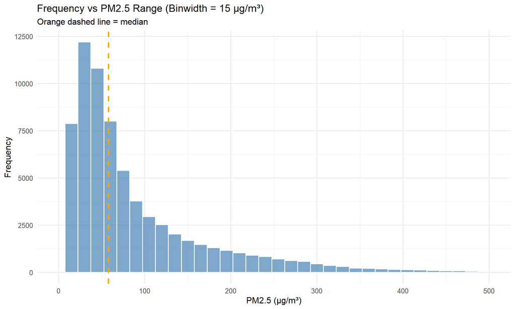

```r
ggplot(pollution, aes(x = PM2.5)) +
  geom_histogram(
    binwidth = 15,
    fill = "steelblue",
    alpha = 0.7,
    color = "white"
  ) +
  geom_vline(
    xintercept = median(pollution$PM2.5, na.rm = TRUE),
    color = "orange",
    linetype = "dashed",
    linewidth = 1
  ) +
  scale_x_continuous(limits = c(0, 500)) +
  labs(
    title = "Frequency vs PM2.5 Range (Binwidth = 15 μg/m³)",
    x = "PM2.5 (μg/m³)",
    y = "Frequency",
    subtitle = "Orange dashed line = median"
  ) +
  theme_minimal(base_size = 12)
```

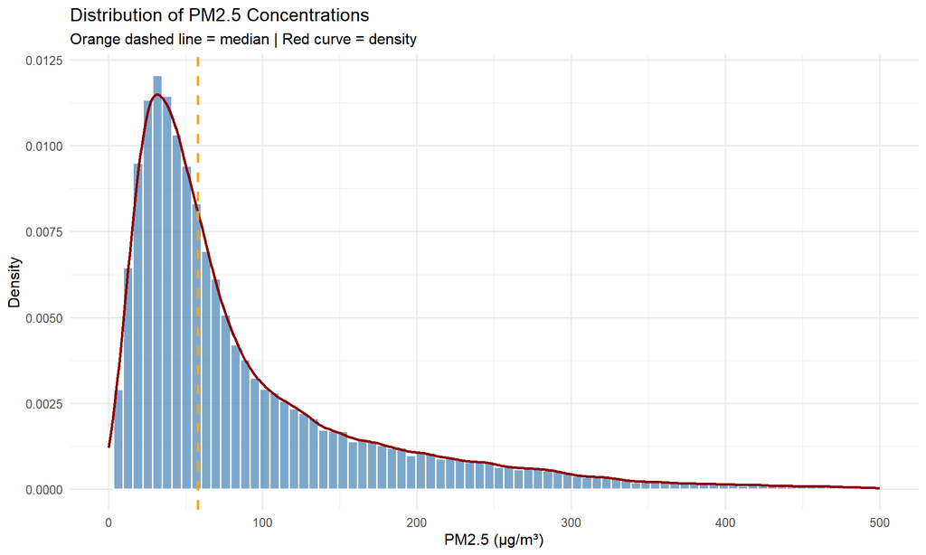

Distribution of PM2.5 concentrations with density overlay

```r
ggplot(pollution, aes(x = PM2.5)) +
  geom_histogram(aes(y = after_stat(density)), bins = 80, fill = "steelblue",
                 alpha = 0.7, color = "white") +
  geom_density(color = "darkred", linewidth = 1) +
  geom_vline(xintercept = median(pollution$PM2.5, na.rm = TRUE),
             color = "orange", linetype = "dashed", linewidth = 1) +
  scale_x_continuous(limits = c(0, 500)) +
  labs(title = "Distribution of PM2.5 Concentrations",
       subtitle = "Orange dashed line = median | Red curve = density",
       x = "PM2.5 (μg/m³)", y = "Density") +
  theme_minimal(base_size = 12)
```

The distribution is **right-skewed**, typical of air pollution data. The long right tail represents pollution episodes, particularly during winter months.

## 3.3 Full Time Series

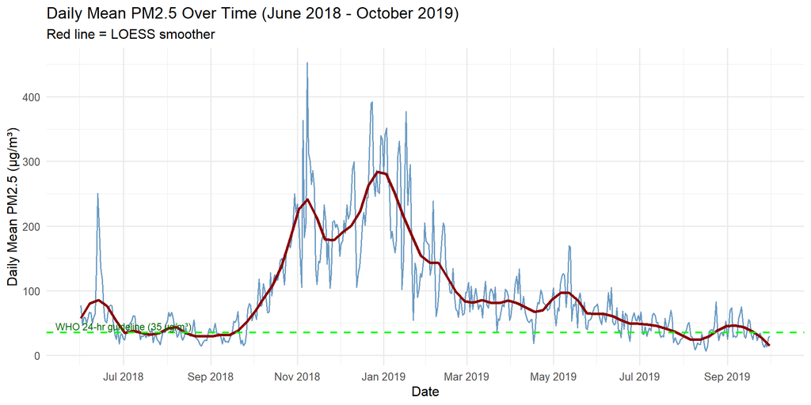

Daily mean PM2.5 over the study period

```r
# Aggregate to daily means for cleaner visualization
daily_pm25 <- pollution %>%
  group_by(date) %>%
  summarise(
    daily_PM25 = mean(PM2.5, na.rm = TRUE),
    .groups = "drop"
  )

ggplot(daily_pm25, aes(x = date, y = daily_PM25)) +
  geom_line(color = "steelblue", alpha = 0.8) +
  geom_smooth(method = "loess", span = 0.1, se = FALSE, color = "darkred",
              linewidth = 1.2) +
  geom_hline(yintercept = 35, color = "green", linetype = "dashed", linewidth = 0.8) +
  annotate("text", x = as.Date("2018-07-01"), y = 45,
           label = "WHO 24-hr guideline (35 μg/m³)", color = "darkgreen", size = 3) +
  labs(title = "Daily Mean PM2.5 Over Time (June 2018 - October 2019)",
       subtitle = "Red line = LOESS smoother",
       x = "Date", y = "Daily Mean PM2.5 (μg/m³)") +
  theme_minimal(base_size = 12) +
  scale_x_date(date_breaks = "2 months", date_labels = "%b %Y")
```

**Key observations:**

- Strong **seasonal pattern** with winter peaks (Nov-Jan) and monsoon lows (Jul-Sep)
- Daily values frequently exceed WHO guideline (35 μg/m³)
- Winter 2018-19 shows extreme episodes exceeding 300 μg/m³

## 3.4 Hourly (Diurnal) Cycle

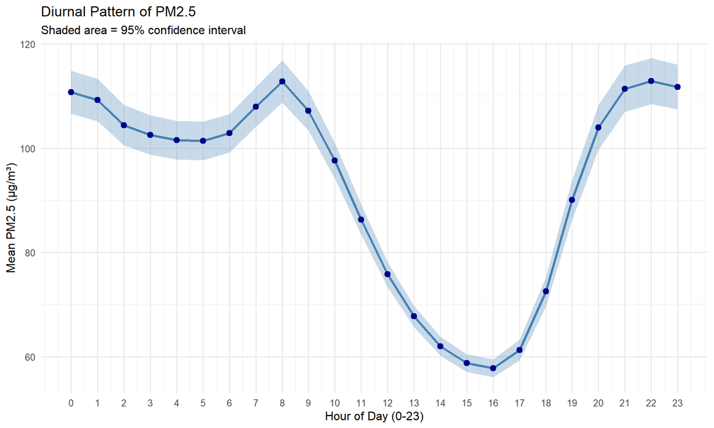

Mean PM2.5 by hour of day

```r
hourly_pattern <- pollution %>%
  group_by(hour_of_day) %>%
  summarise(
    mean_PM25 = mean(PM2.5, na.rm = TRUE),
    se_PM25 = sd(PM2.5, na.rm = TRUE) / sqrt(n()),
    .groups = "drop"
  )

ggplot(hourly_pattern, aes(x = hour_of_day, y = mean_PM25)) +
  geom_ribbon(aes(ymin = mean_PM25 - 1.96*se_PM25,
                  ymax = mean_PM25 + 1.96*se_PM25),
              fill = "steelblue", alpha = 0.3) +
  geom_line(color = "steelblue", linewidth = 1.2) +
  geom_point(color = "darkblue", size = 2.5) +
  scale_x_continuous(breaks = 0:23) +
  labs(title = "Diurnal Pattern of PM2.5",
       subtitle = "Shaded area = 95% confidence interval",
       x = "Hour of Day (0-23)", y = "Mean PM2.5 (μg/m³)") +
  theme_minimal(base_size = 12)
```

```r
peak_hour <- hourly_pattern$hour_of_day[which.max(hourly_pattern$mean_PM25)]
low_hour <- hourly_pattern$hour_of_day[which.min(hourly_pattern$mean_PM25)]
cat("Peak PM2.5 hour:", peak_hour, ":00\n")
```

```
## Peak PM2.5 hour: 22 :00
```

```r
cat("Lowest PM2.5 hour:", low_hour, ":00\n")
```

```
## Lowest PM2.5 hour: 16 :00
```

**Interpretation:**

- **Peak hours:** Morning (8-10 AM) and late evening (9-11 PM) - coinciding with rush hour traffic and shallow boundary layer
- **Minimum:** Afternoon (2-4 PM) - when convective mixing is strongest and pollutants disperse vertically

## 3.5 Day-of-Week Pattern

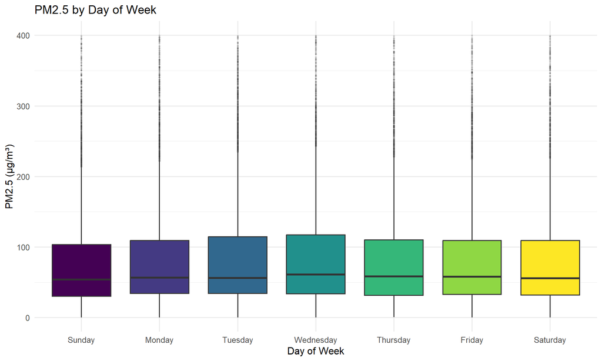

PM2.5 distribution by day of week

```r
ggplot(pollution, aes(x = dow, y = PM2.5, fill = dow)) +
  geom_boxplot(outlier.alpha = 0.1, outlier.size = 0.5) +
  scale_y_continuous(limits = c(0, 400)) +
  scale_fill_viridis_d() +
  labs(title = "PM2.5 by Day of Week",
       x = "Day of Week", y = "PM2.5 (μg/m³)") +
  theme_minimal(base_size = 12) +
  theme(legend.position = "none")
```

```r
weekend_compare <- pollution %>%
  group_by(is_weekend) %>%
  summarise(
    Mean_PM25 = mean(PM2.5, na.rm = TRUE),
    Median_PM25 = median(PM2.5, na.rm = TRUE),
    .groups = "drop"
  ) %>%
  mutate(Period = ifelse(is_weekend, "Weekend", "Weekday"))

weekend_compare %>%
  select(Period, Mean_PM25, Median_PM25) %>%
  kable(caption = "Weekday vs Weekend PM2.5", digits = 2) %>%
  kable_styling(bootstrap_options = c("striped", "hover"), full_width = FALSE)
```

Weekday vs Weekend PM2.5

| Period | Mean_PM25 | Median_PM25 |
| --- | --- | --- |
| Weekday | 94.15 | 59 |
| Weekend | 89.88 | 56 |

The weekday-weekend difference is **modest** in Delhi compared to Western cities, likely because:

- Delhi has less rigid work schedules
- Traffic and commercial activity persist on weekends
- Dominant pollution sources (dust, burning) are not work-schedule dependent

## 3.6 Monthly/Seasonal Pattern

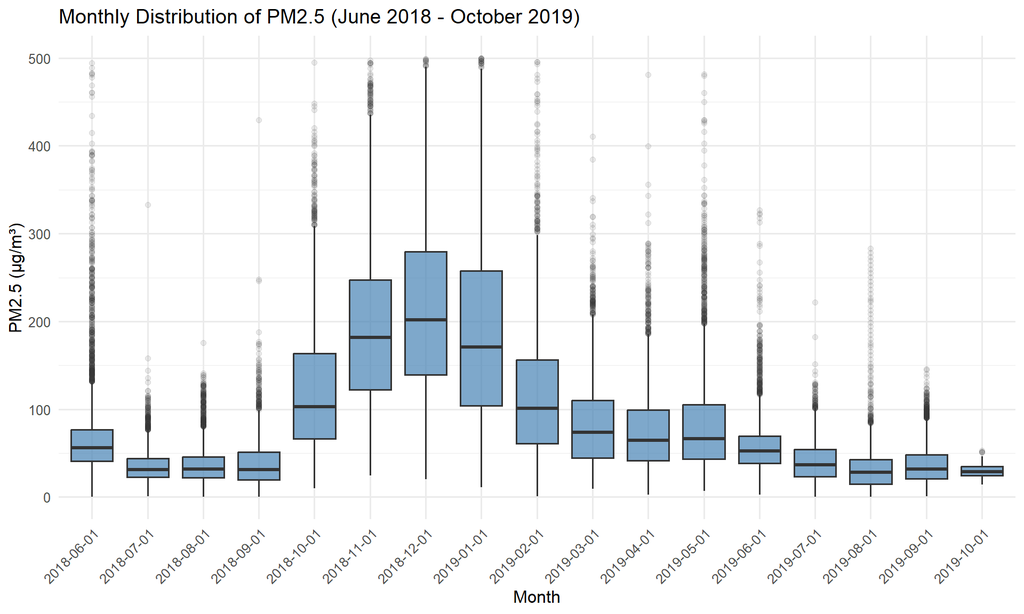

Monthly distribution of PM2.5

```r
pollution <- pollution %>%
  mutate(year_month = floor_date(date, "month"))

ggplot(pollution, aes(x = factor(year_month), y = PM2.5)) +
  geom_boxplot(fill = "steelblue", alpha = 0.7, outlier.alpha = 0.1) +
  scale_y_continuous(limits = c(0, 500)) +
  labs(title = "Monthly Distribution of PM2.5 (June 2018 - October 2019)",
       x = "Month", y = "PM2.5 (μg/m³)") +
  theme_minimal(base_size = 12) +
  theme(axis.text.x = element_text(angle = 45, hjust = 1))
```

**Seasonal Interpretation:**

[output not shown]